# Лабораторная работа №8

Адресация IPv4 и IPv6. Настройка маршрутизации

Авдадаев Джамал Геланиевич

04 февраля 2026

# Цель работы

## Основная цель

Изучение принципов маршрутизации в IPv4- и IPv6-сетях и практическая настройка сетевого оборудования в среде моделирования **GNS3**.

# Ход выполнения работы

## Топология IPv6–IPv4

- Построена сеть в **GNS3**:
  - 3 маршрутизатора **VyOS**
  - 2 коммутатора Ethernet
  - 2 оконечных устройства **VPCS**
- Подключён анализатор трафика между **gw-01** и **gw-03**

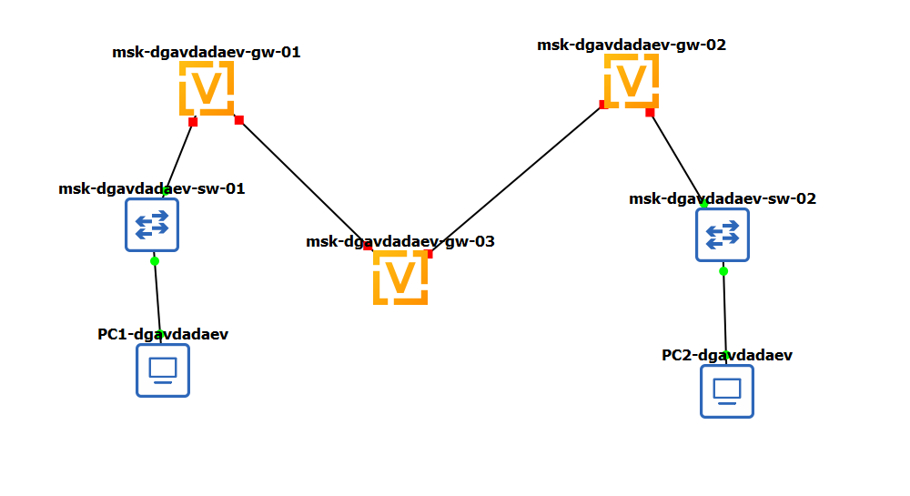

Топология сети IPv6–IPv4

## Настройка IPv6 на PC1

- Назначен адрес: `1000::a/64`
- Конфигурация сохранена (`save`)
- Проверка параметров (`show ipv6`)

[figure not shown]

Настройка IPv6 на PC1

## Настройка IPv6 на PC2

- Назначен адрес: `1002::a/64`
- Конфигурация сохранена (`save`)
- Проверка параметров (`show ipv6`)

[figure not shown]

Настройка IPv6 на PC2

## Настройка VyOS gw-01

- `eth0`: IPv6 `1000::1/64` (LAN)
- `eth1`: IPv4 `10.0.0.1/8` (к gw-03)
- Включён Router Advertisement для `1000::/64`

[figure not shown]

Конфигурация msk-dgavdadaev-gw-01

## Настройка VyOS gw-02

- `eth0`: IPv6 `1002::1/64` (LAN)
- `eth1`: IPv4 `20.0.0.2/8` (к gw-03)
- Включён Router Advertisement для `1002::/64`

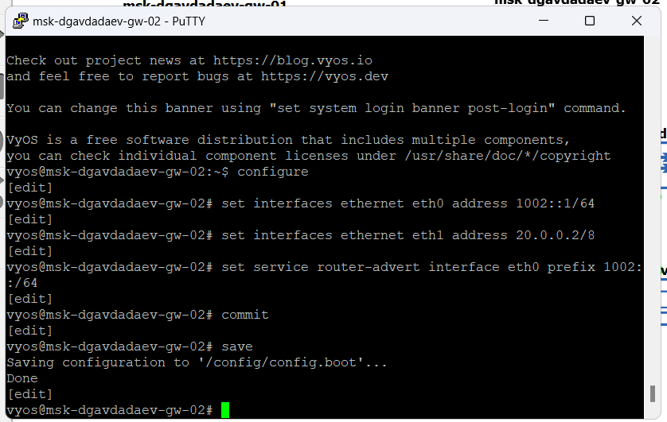

Конфигурация msk-dgavdadaev-gw-02

## Настройка VyOS gw-03

- Транзитный IPv4-узел
- `eth0`: `10.0.0.2/8`
- `eth1`: `20.0.0.1/8`

[figure not shown]

Конфигурация msk-dgavdadaev-gw-03

## Проверка RA и шлюза по умолчанию

[figure not shown]

Проверка IPv6 на PC1

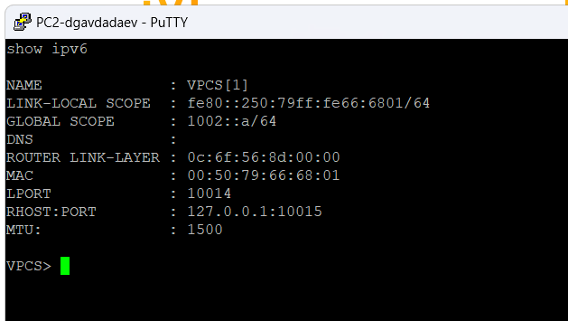

Проверка IPv6 на PC2

## Проверка IPv4 до маршрутизации

- Успешный ping: `10.0.0.2`
- Ошибка *Network is unreachable* для `20.0.0.1` и `20.0.0.2`
- Причина: нет маршрутов к `20.0.0.0/8`

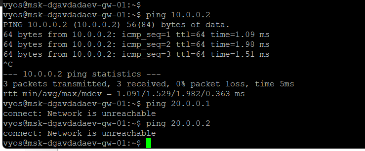

Проверка ping с gw-01

## Анализ ICMP и ARP

- Зафиксированы:
  - ICMP Echo Request / Reply
  - ARP-запросы и ответы

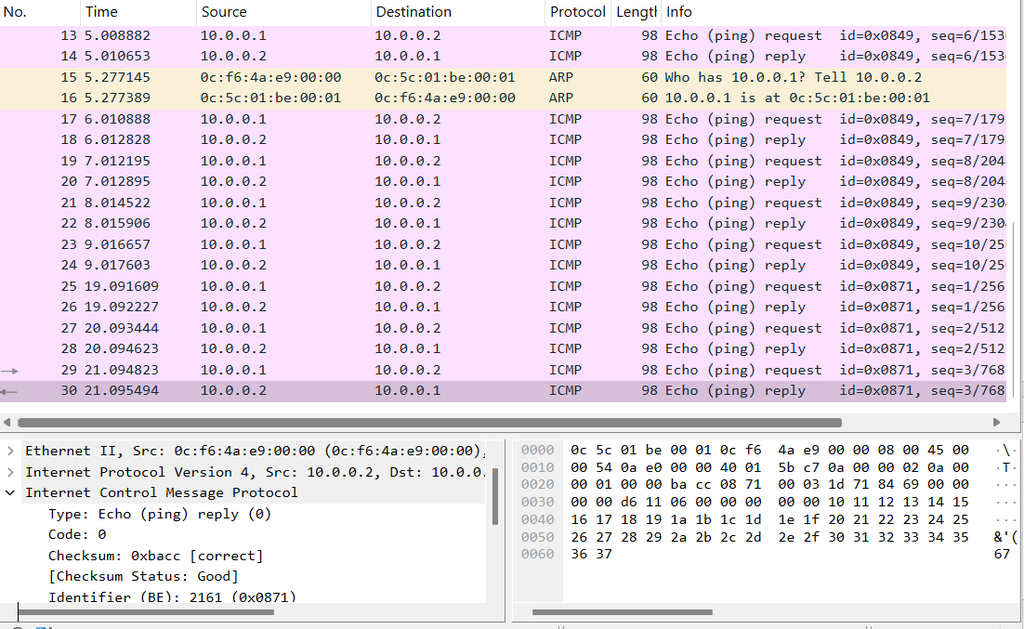

Анализ ICMP и ARP трафика

## Настройка RIP на gw-01

- Добавлена сеть: `10.0.0.0/8`
- Конфигурация применена и сохранена

[figure not shown]

Настройка RIP на msk-dgavdadaev-gw-01

## Настройка RIP на gw-02

- Добавлена сеть: `20.0.0.0/8`
- Конфигурация применена и сохранена

[figure not shown]

Настройка RIP на msk-dgavdadaev-gw-02

## Настройка RIP на gw-03

- Участие сразу в двух сетях:
  - `10.0.0.0/8`
  - `20.0.0.0/8`

[figure not shown]

Настройка RIP на msk-dgavdadaev-gw-03

## Проверка IPv4 после RIP

- Узлы `20.0.0.1` и `20.0.0.2` стали доступны
- Подтверждена корректная динамическая маршрутизация

[figure not shown]

Проверка ping после настройки RIP

## Анализ RIP и ICMP трафика

- В трафике наблюдаются:
  - RIPv2 на `224.0.0.9`
  - ICMP Echo Request / Reply
  - ARP

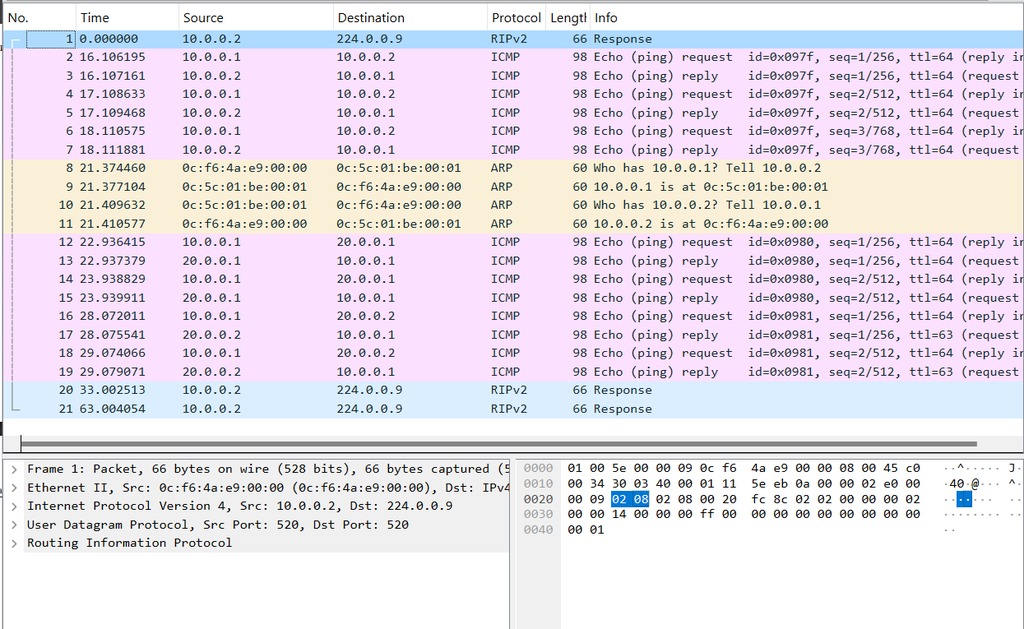

Анализ RIP и ICMP трафика

## Настройка туннеля на gw-01

- Интерфейс: `tun0`
- SIT, источник IPv4: `10.0.0.1`, удалённый: `20.0.0.2`
- IPv6 туннеля: `1001::1/64`

[figure not shown]

Настройка туннеля на msk-dgavdadaev-gw-01

## Настройка туннеля на gw-02

- Интерфейс: `tun0`
- SIT, источник IPv4: `20.0.0.2`, удалённый: `10.0.0.1`
- IPv6 туннеля: `1001::2/64`

[figure not shown]

Настройка туннеля на msk-dgavdadaev-gw-02

## Статическая маршрутизация IPv6

- На gw-01: маршрут к `1002::/64` через `1001::2`
- На gw-02: маршрут к `1000::/64` через `1001::1`

[figure not shown]

Статический IPv6-маршрут на msk-dgavdadaev-gw-01

[figure not shown]

Статический IPv6-маршрут на msk-dgavdadaev-gw-02

## Ping и traceroute с PC1

- Успешный `ping` до `1002::a`
- Трассировка подтверждает прохождение через туннель

[figure not shown]

Ping и traceroute с PC1

## Ping и traceroute с PC2

- Успешный `ping` до `1000::a`
- Подтверждена симметричная IPv6-доступность

[figure not shown]

Ping и traceroute с PC2

## Общий вид трафика IPv6 через IPv4

- IPv6-пакеты инкапсулируются в IPv4
- Используется протокол **41**
- IPv4-адреса соответствуют концам туннеля

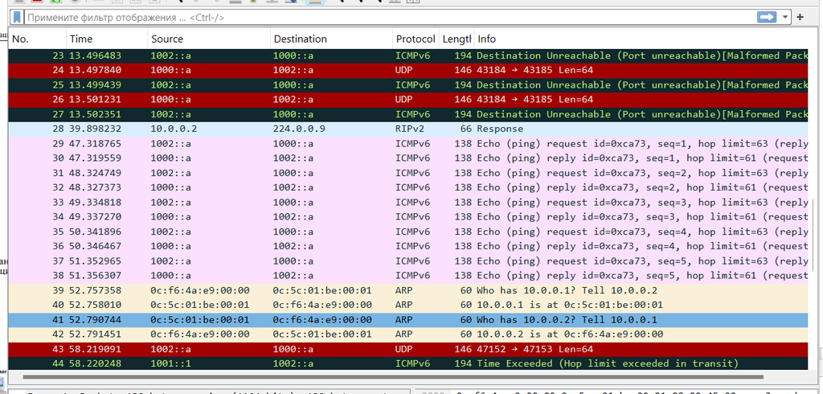

Общий вид трафика IPv6 через IPv4

## Детализация инкапсуляции

- В полезной нагрузке IPv4 содержится полный IPv6-заголовок
- ICMPv6 Echo Request / Reply видны внутри инкапсуляции

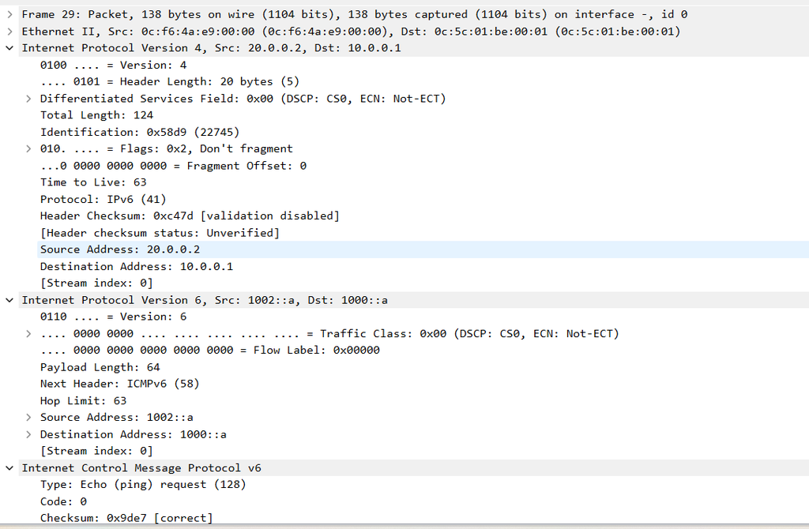

Детализация инкапсуляции IPv6 в IPv4

# Итоги работы

## Заключение

В ходе работы была реализована связность IPv4- и IPv6-сетей в **GNS3**: настроена адресация, динамическая маршрутизация IPv4 (RIP) и туннель **IPv6-over-IPv4 (SIT)** со статической маршрутизацией IPv6. Проверка связности и анализ трафика в **Wireshark** подтвердили корректную работу протоколов **ARP**, **ICMP**, **ICMPv6** и **RIP**, а также механизмов инкапсуляции IPv6 в IPv4 (протокол 41).